# STAT 331/531 Final Project: Basketball Analysis Lab

Author

Elaina Chao, Natalie Murai, Nathan Munoz

Download .qmd starter file

Download cbb.csv

## Introduction

In this lab, we will analyze Division I college basketball data from the 2013-2026 seasons. The dataset includes team statistics such as wins, losses, offensive efficiency, defensive efficiency, strength of schedule, and tournament-related performance measures.

The goal of this lab is to practice data wrangling, visualization, and functional programming skills using real sports analytics data. This dataset works well for the lab because it contains multiple years of observations, categorical and numeric variables, opportunities for grouping and summarizing, and enough complexity for writing functions and iteration tasks.

## Dataset Source

College Basketball Dataset from Kaggle: https://www.kaggle.com/datasets/andrewsundberg/college-basketball-dataset/data

## Data Dictionary: Selected Variables

| Variable | Description |
| --- | --- |
| `TEAM` | Team name |
| `CONF` | Conference |
| `YEAR` | Season year |
| `G` | Games played |
| `W` | Wins |
| `ADJOE` | Adjusted offensive efficiency |
| `ADJDE` | Adjusted defensive efficiency |
| `BARTHAG` | Power rating metric |
| `EFG_O` | Effective field goal percentage on offense |
| `EFG_D` | Effective field goal percentage allowed on defense |
| `TOR` | Turnover rate |
| `WAB` | Wins above bubble |

## Learning Goals

This lab is intended to assess the following skills:

1. Using `dplyr` verbs for efficient data manipulation.
2. Creating data visualizations with `ggplot2`.
3. Writing functions that take user inputs and return data frame outputs.
4. Using string and data-cleaning tools to prepare data for analysis.
5. Interpreting statistical graphics and summaries in context.
6. Simulation

## Setup

```r
library(tidyverse)
library(kableExtra)

basketball <- read_csv("cbb.csv")
```

# Lab Questions

**Tip**

For questions where you display rows of a data frame, try to only print the rows and columns needed to answer the question.

## Question 1: Data Wrangling

Create a new dataset containing only teams from the 2024 season.

Then:

1. Select the variables `TEAM`, `CONF`, `W`, `ADJOE`, and `ADJDE`.
2. Arrange the teams from most wins to fewest wins.
3. Display the first 10 rows.

### Solution

```r
basketball_2024 <- basketball |>
  filter(YEAR == 2024) |>
  select(TEAM, CONF, W, ADJOE, ADJDE) |>
  arrange(desc(W))

head(basketball_2024, 10)
```

```
# A tibble: 10 × 5
   TEAM          CONF      W ADJOE ADJDE
   <chr>         <chr> <dbl> <dbl> <dbl>
 1 Connecticut   BE       31  127.  93.6
 2 James Madison SB       31  112  100.
 3 Houston       B12      30  119.  85.5
 4 McNeese St.   Slnd     30  111. 101
 5 Purdue        B10      29  126.  94.7
 6 Grand Canyon  WAC      29  111.  99.8
 7 Samford       SC       29  112. 102.
 8 Drake         MVC      28  115. 100.
 9 Vermont       AE       28  104.  98.7
10 Indiana St.   MVC      28  118. 101.
```

## Question 2: Visualization

Using the 2024 season data, create a scatterplot showing the relationship between adjusted offensive efficiency (`ADJOE`) and adjusted defensive efficiency (`ADJDE`).

Before making the plot, use `fct_collapse()` to create a new variable called `conference_region` that groups conferences into East, Central, and West regions.

Then:

1. Look at the defined conference regions.
2. Use `fct_collapse()` to create `conference_region`.
3. Create a scatterplot with `ADJOE` on the x-axis and `ADJDE` on the y-axis.
4. Color the points by `conference_region`.
5. Include a title, axis labels, and a legend label.

**Note**

In this dataset, higher `ADJOE` values represent stronger offensive efficiency, while lower `ADJDE` values represent stronger defensive efficiency.

### Solution

```r
east_confs <- c("A10", "ACC", "AE", "Amer", "ASun", "BE", "BSth",
                "CAA", "Ivy", "MAAC", "MEAC", "NEC", "Pat", "SC", "SEC")
central_confs <- c("B10", "B12", "CUSA", "Horz", "MAC", "MVC",
  "OVC", "SB", "Slnd", "Sum", "SWAC", "ind")
west_confs <- c("BSky", "BW", "MWC", "P12", "WAC", "WCC")
```

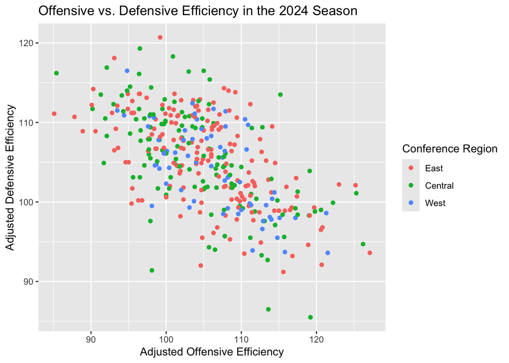

```r
basketball_2024 <- basketball_2024 |>
  mutate(
    conference_region = fct_collapse(
      .f = CONF,
      "East" = east_confs,
      "Central" = central_confs,
      "West" = west_confs))
basketball_2024 |>
  ggplot(aes(x = ADJOE, y = ADJDE, color = conference_region)) +
  geom_point() +
  labs(title = "Offensive vs. Defensive Efficiency in the 2024 Season",
    x = "Adjusted Offensive Efficiency",
    y = "Adjusted Defensive Efficiency",
    color = "Conference Region")
```

Strong teams generally appear with high offensive efficiency and low defensive efficiency. Some conferences may show visible clustering, suggesting similar performance levels among teams in the same conference.

## Question 3: Functions

Write a function called `top_team()` that:

- takes a conference name as input,
- filters the dataset to the 2024 season,
- and returns the team with the highest number of wins in that conference.

Test your function using the `"WCC"` and `"SEC"` conferences.

**Tip**

Your function should return the team, conference, and wins.

### Solution

```r
top_team <- function(conf_name) {
  basketball |>
    filter(YEAR == 2024, CONF == conf_name) |>
    arrange(desc(W)) |>
    slice_max(W) |>
    select(TEAM, CONF, W)
}
```

```r
top_team("WCC")
```

```
# A tibble: 1 × 3
  TEAM         CONF      W
  <chr>        <chr> <dbl>
1 Saint Mary's WCC      26
```

```r
top_team("SEC")
```

```
# A tibble: 1 × 3
  TEAM   CONF      W
  <chr>  <chr> <dbl>
1 Auburn SEC      27
```

## Question 4: More Data Wrangling

Compare conference performance between the 2013 and 2024 seasons. For each conference, calculate the median adjusted offensive efficiency and median adjusted defensive efficiency in both years.

- Create one row for each conference.
- Include columns for 2013 offense, 2024 offense, offense change, 2013 defense, 2024 defense, and defense change.
- Arrange the table from largest offensive improvement to smallest offensive improvement.
- Print only the conference name which had the largest offensive improvement.
- Save your final table as `conference_table`.

**Tip**

This will require transforming your data! Sketch out what you want the final table to look like before you begin coding.

You should be starting with the full basketball dataset and ending with one row per conference.

**Tip**

Use the `median()` function to find the typical `ADJOE` and `ADJDE` values for each conference in each year.

Offensive/defensive changes can be calculated as: `median_offense_2024 - median_offense_2013`

Hint: You may need to use ungroup() for your output portion ;)

### Solution

```r
conference_table <- basketball |>
  filter(YEAR == 2013 | YEAR == 2024) |>
  group_by(CONF, YEAR) |>
  summarize(
    median_offense = median(ADJOE, na.rm = TRUE),
    median_defense = median(ADJDE, na.rm = TRUE)
  ) |>
  pivot_wider(
    names_from = YEAR,
    values_from = c(median_offense, median_defense)
  ) |>
  mutate(
    offense_change = median_offense_2024 - median_offense_2013,
    defense_change = median_defense_2024 - median_defense_2013
  ) |>
  drop_na()|>
  arrange(desc(offense_change))
```

### Print only the conference name which had the largest offensive improvement.

```r
conference_table |>
  ungroup() |>
  slice_max(offense_change) |>
  pull(CONF)
```

```
[1] "SC"
```

## Question 5: Table Cleaning with KableExtra

Using the `conference_table` you created in Question 4, make a cleanly formatted table that displays the top 8 conferences by their median offense in 2024.

**Tip**

You should not need to recreate the table from Question 4. Start with your saved `conference_table`, then use data manipulation, `kable()`, and `kable_styling()` to format the output.

If your table contains NA values, consider adding `drop_na()` to your data wrangling in question 4.

### Solution

```r
conference_table |>
  ungroup() |>
  slice_max(median_offense_2024, n = 8) |>
  mutate(
    offensive_improvement = case_when(
      offense_change >= 5 ~ "Significantly",
      offense_change < 5 & offense_change > 0 ~ "Slightly",
      offense_change == 0 ~ "No Change",
      offense_change < 0 ~ "Got Worse")) |>
 select(
  CONF,
  median_offense_2024,
  offense_change,
  offensive_improvement) |>
  kable(
    caption = "Top 8 Conferences by 2024 Median Offensive Efficiency",
    col.names = c(
      "Conference",
      "2024 Median Offense",
      "Offense Change",
      "Improved Offensively?"
    ),
    digits = 2
  ) |>
  kable_styling(
    full_width = FALSE,
    bootstrap_options = "striped"
  )
```

Top 8 Conferences by 2024 Median Offensive Efficiency

| Conference | 2024 Median Offense | Offense Change | Improved Offensively? |
| --- | --- | --- | --- |
| B10 | 114.75 | 5.30 | Significantly |
| SEC | 114.00 | 9.80 | Significantly |
| B12 | 113.55 | 4.85 | Slightly |
| ACC | 111.80 | 5.05 | Significantly |
| BE | 111.60 | 4.30 | Slightly |
| MWC | 111.50 | 5.50 | Significantly |
| P12 | 111.40 | 5.00 | Significantly |
| WCC | 107.90 | 2.70 | Slightly |

## Question 6: More Functions

Write a function called `win_ratio()`. The function should be able to:

1. Take a data frame, team name, and year as input.
2. Filter to that team and year.
3. Calculate the team’s win ratio using wins divided by games played.
4. Return only that ratio.

### Solution

```r
win_ratio <- function(df, team_name, year) {
  df |>
    filter(TEAM == team_name, YEAR == year) |>
    summarize(win_ratio = W / G) |>
    pull(win_ratio)
}
```

### Test your function using the following code chunk:

```r
win_ratio(basketball, "Drake", 2013)
```

```
[1] 0.4516129
```

## Question 7: Functions with Simulation

Write a function called `simulate_match()`. The function should be able to:

1. Take a data frame, two team names, and a year as input.
2. Use `win_ratio()` to calculate each team’s win ratio for that year.
3. Use those win ratios to estimate the probability that the first team wins.
4. Simulate one game between the two teams.
5. Return the name of the winning team.

**Note**

For this simulation, we are using a simple Bradley-Terry style model. The probability that Team 1 wins is based on Team 1’s win ratio compared to the total win ratio of both teams.

$$P(\text{Team 1 Wins}) =
\frac{\text{Team 1 Win Ratio}}
{\text{Team 1 Win Ratio} + \text{Team 2 Win Ratio}}$$

### Solution

```r
simulate_match <- function(df, team1, team2, year) {
  team1_ratio <- win_ratio(df, team1, year)
  team2_ratio <- win_ratio(df, team2, year)

  prob_team1 <- team1_ratio / (team1_ratio + team2_ratio)

  winner <- sample(
    x = c(team1, team2),
    size = 1,
    prob = c(prob_team1, 1 - prob_team1)
  )

  winner
}
```

## Question 8: Simulation with map_chr

Use `map_chr()` to simulate 1,000 games between two teams of your choice during the 2024 season.

Then:

1. Save your results to an object.
2. Convert the results into a data frame using enframe()
3. Count how many simulations each team won.
4. Calculate the proportion of simulations won by each team.
5. Display your final output using `kable()`

**Tip**

Remember to use set.seed() for reproducibility

### Solution

```r
set.seed(2005)
results <- map_chr(
  .x = 1:1000,
  .f = ~ simulate_match(
    df = basketball,
    team1 = "Connecticut",
    team2 = "DePaul",
    year = 2024
  )
)

results |>
  enframe(name = "sim", value = "winner") |>
  count(winner) |>
  mutate(prop_won = n / sum(n)) |>
  kable(
    caption = "Simulated Results: Connecticut vs. DePaul",
    col.names = c("Winning Team", "Number of Wins", "Proportion Won")
  )
```

Simulated Results: Connecticut vs. DePaul

| Winning Team | Number of Wins | Proportion Won |
| --- | --- | --- |
| Connecticut | 910 | 0.91 |
| DePaul | 90 | 0.09 |